# StandR_Demo

Carme Delicado

2025-11-18

### 1. Preparación del entorno de trabajo

# Instalación de paquetes necesarios

Como ya tenemos instalado BiocManager, instalamos directamete StandR. Usamos buils_vignettes = TRUE, ya que eso nos permitirá abrir el archivo HTML.

# Cargar librerías

```r
library(standR)
library(tidyverse)
library(SpatialExperiment)
library(ggplot2)
library(ggalluvial)
library(dplyr)
library(ggforce)
library(networkD3)
library(ggrepel)
```

### 2.Uso de standR para procesar y analizar datos transcriptómicos de GeoMx.

# 2.1 Cargar datos

Este conjunto de datos incluye información de cinco láminas. La estrategia de selección de los ROI está basada en regiones celulares, centrado principalmente en cinco estructuras que se encuentran en el ganglio linfático:

- La zona de células B
- La zona de células T
- El centro germinal
- La médula
- La trabécula

Elegir directorio de trabajo.

```r
datadir <- (system.file("extdata", package = "GeoMXAnalysisWorkflow"))

setwd(datadir)

list.files(datadir)
```

```
## [1] "convertDataToList.R" "count.txt"           "genemeta.txt"
## [4] "metadata.txt"
```

Abrimos los tres archivos(.txt) y los convertimos en data.frame que serán nuestros objetos de trabajo.

```r
countFile <- read_tsv(file.path(datadir, "count.txt")) %>% as.data.frame()

sampleAnnoFile <- read_tsv(file.path(datadir,"metadata.txt")) %>% as.data.frame()

featureAnnoFile <- read_tsv(file.path(datadir,"genemeta.txt")) %>% as.data.frame()
```

Visualizamos las primeras y filas y columnas para tener una idea de como son nuestros archivos.

```r
dim(countFile)
```

```
## [1] 18677   191
```

```r
head(countFile)[,1:5]
```

|  | TargetName | 32 \| 001 \| Full ROI | 32 \| 002 \| Full ROI | 32 \| 003 \| Full ROI | 32 \| 004 \| Full ROI |
| --- | --- | --- | --- | --- | --- |
| 1 | H3C13 | 6 | 22 | 12 | 20 |
| 2 | ATXN7L1 | 5 | 2 | 6 | 8 |
| 3 | TCERG1 | 6 | 6 | 10 | 14 |
| 4 | CLIC6 | 3 | 1 | 3 | 2 |
| 5 | MAPK1IP1L | 23 | 23 | 29 | 35 |
| 6 | ZNF614 | 2 | 10 | 8 | 6 |

```r
dim(sampleAnnoFile)
```

```
## [1] 190  32
```

```r
head(sampleAnnoFile)[,1:5]
```

|  | SlideName | ScanLabel | ROILabel | SegmentLabel | SegmentDisplayName |
| --- | --- | --- | --- | --- | --- |
| 1 | hu_lymph_node_001a | 6B | 001 | Full ROI | 6B \| 001 \| Full ROI |
| 2 | hu_lymph_node_001a | 6B | 002 | Full ROI | 6B \| 002 \| Full ROI |
| 3 | hu_lymph_node_001a | 6B | 003 | Full ROI | 6B \| 003 \| Full ROI |
| 4 | hu_lymph_node_001a | 6B | 004 | Full ROI | 6B \| 004 \| Full ROI |
| 5 | hu_lymph_node_001a | 6B | 005 | Full ROI | 6B \| 005 \| Full ROI |
| 6 | hu_lymph_node_001a | 6B | 006 | Full ROI | 6B \| 006 \| Full ROI |

```r
dim(featureAnnoFile)
```

```
## [1] 18677    13
```

```r
head(featureAnnoFile)[,1:5]
```

|  | TargetName | HUGOSymbol | TargetGroup | AnalyteType | CodeClass |
| --- | --- | --- | --- | --- | --- |
| 1 | H3C13 | H3-2,H3P4,H3C13 | All Targets | RNA | Endogenous |
| 2 | ATXN7L1 | ATXN7L1 | All Targets | RNA | Endogenous |
| 3 | TCERG1 | TCERG1 | All Targets | RNA | Endogenous |
| 4 | CLIC6 | CLIC6 | All Targets | RNA | Endogenous |
| 5 | MAPK1IP1L | MAPK1IP1L | All Targets | RNA | Endogenous |
| 6 | ZNF614 | ZNF614 | All Targets | RNA | Endogenous |

Juntamos los Datasets en un único objeto.

```r
datos <- (readGeoMx(countFile, sampleAnnoFile, featureAnnoFile))
datos
```

```
## class: SpatialExperiment
## dim: 18676 190
## metadata(1): NegProbes
## assays(2): counts logcounts
## rownames(18676): H3C13 ATXN7L1 ... FEZ1 PGLS
## rowData names(12): HUGOSymbol TargetGroup ... NumberOfProbesTotal
##   GeneID
## colnames(190): 32 | 001 | Full ROI 32 | 002 | Full ROI ... 25337T4(2) |
##   034 | CD20+ 25337T4(2) | 034 | SMA+
## colData names(32): SlideName ScanLabel ... Type sample_id
## reducedDimNames(0):
## mainExpName: NULL
## altExpNames(0):
## spatialCoords names(2) : ROICoordinateX ROICoordinateY
## imgData names(0):
```

Chequeamos la información básica.

Vemos que tenemos 18676 genes y 190 ROIs.

Los conteos de los tránscritos se guardan en la sección assay, como conteos crudos y logcounts.

```r
assayNames(datos)
```

```
## [1] "counts"    "logcounts"
```

```r
assay(datos, "counts")[1:5, 1:5]
```

|  | 32 \| 001 \| Full ROI | 32 \| 002 \| Full ROI | 32 \| 003 \| Full ROI | 32 \| 004 \| Full ROI | 32 \| 005 \| Full ROI |
| --- | --- | --- | --- | --- | --- |
| H3C13 | 6 | 22 | 12 | 20 | 12 |
| ATXN7L1 | 5 | 2 | 6 | 8 | 4 |
| TCERG1 | 6 | 6 | 10 | 14 | 4 |
| CLIC6 | 3 | 1 | 3 | 2 | 5 |
| MAPK1IP1L | 23 | 23 | 29 | 35 | 23 |

```r
assay(datos, "logcounts")[1:5, 1:5]
```

```
##           32 | 001 | Full ROI 32 | 002 | Full ROI 32 | 003 | Full ROI
## H3C13                5.566671            7.361391            5.794760
## ATXN7L1              5.312797            4.028661            4.833464
## TCERG1               5.566671            5.521811            5.539550
## CLIC6                4.611902            3.156275            3.907891
## MAPK1IP1L            7.470903            7.424945            7.044597
##           32 | 004 | Full ROI 32 | 005 | Full ROI
## H3C13                6.487543            6.226214
## ATXN7L1              5.201566            4.698285
## TCERG1               5.983333            4.698285
## CLIC6                3.369000            5.003339
## MAPK1IP1L            7.284459            7.150834
```

Los metadatos de los ROI se almacenan en el colData del objeto.

```r
colData(datos)[1:5,1:5]
```

```
## DataFrame with 5 rows and 5 columns
##                              SlideName   ScanLabel    ROILabel SegmentLabel
##                            <character> <character> <character>  <character>
## 32 | 001 | Full ROI hu_lymph_node_001b          32         001     Full ROI
## 32 | 002 | Full ROI hu_lymph_node_001b          32         002     Full ROI
## 32 | 003 | Full ROI hu_lymph_node_001b          32         003     Full ROI
## 32 | 004 | Full ROI hu_lymph_node_001b          32         004     Full ROI
## 32 | 005 | Full ROI hu_lymph_node_001b          32         005     Full ROI
##                          CD3+
##                     <logical>
## 32 | 001 | Full ROI     FALSE
## 32 | 002 | Full ROI     FALSE
## 32 | 003 | Full ROI     FALSE
## 32 | 004 | Full ROI     FALSE
## 32 | 005 | Full ROI     FALSE
```

Los metadatos de los genes se almacenan en el rowData del objeto.

```r
rowData(datos)[1:5,1:5]
```

```
## DataFrame with 5 rows and 5 columns
##                HUGOSymbol TargetGroup AnalyteType   CodeClass   ProbePool
##               <character> <character> <character> <character> <character>
## H3C13     H3-2,H3P4,H3C13 All Targets         RNA  Endogenous          01
## ATXN7L1           ATXN7L1 All Targets         RNA  Endogenous          01
## TCERG1             TCERG1 All Targets         RNA  Endogenous          01
## CLIC6               CLIC6 All Targets         RNA  Endogenous          01
## MAPK1IP1L       MAPK1IP1L All Targets         RNA  Endogenous          01
```

Las negative probes son controles diseñados para medir el nivel de ruido de fondo en un experimento de transcriptómica espacial. Con la función de readGeoMx, ya se incluyen estos parámetros en metadata.

```r
metadata(datos)$NegProbes[,1:5]
```

|  | 32 \| 001 \| Full ROI | 32 \| 002 \| Full ROI | 32 \| 003 \| Full ROI | 32 \| 004 \| Full ROI | 32 \| 005 \| Full ROI |
| --- | --- | --- | --- | --- | --- |
| NegProbe-WTX | 1.828305 | 1.434654 | 2.187668 | 2.464718 | 1.747295 |

En el archivo de metadatos generado por Nanostring hay una columna llamada “QCFlags”, que indica las muestras de tejido de mala calidad según su paso preliminar de control de calidad. Si los datos superan correctamente su QC habrá valores NA o celdas vacías en esa columna.

```r
colData(datos)$QCFlags
```

```
##   [1] NA NA NA NA NA NA NA NA NA NA NA NA NA NA NA NA NA NA NA NA NA NA NA NA NA
##  [26] NA NA NA NA NA NA NA NA NA NA NA NA NA NA NA NA NA NA NA NA NA NA NA NA NA
##  [51] NA NA NA NA NA NA NA NA NA NA NA NA NA NA NA NA NA NA NA NA NA NA NA NA NA
##  [76] NA NA NA NA NA NA NA NA NA NA NA NA NA NA NA NA NA NA NA NA NA NA NA NA NA
## [101] NA NA NA NA NA NA NA NA NA NA NA NA NA NA NA NA NA NA NA NA NA NA NA NA NA
## [126] NA NA NA NA NA NA NA NA NA NA NA NA NA NA NA NA NA NA NA NA NA NA NA NA NA
## [151] NA NA NA NA NA NA NA NA NA NA NA NA NA NA NA NA NA NA NA NA NA NA NA NA NA
## [176] NA NA NA NA NA NA NA NA NA NA NA NA NA NA NA
```

No tenemos ninguna muestra de mala calidad.

Para mejor visualización de las muestras de metadata hacemos un diagrama de Sankey.

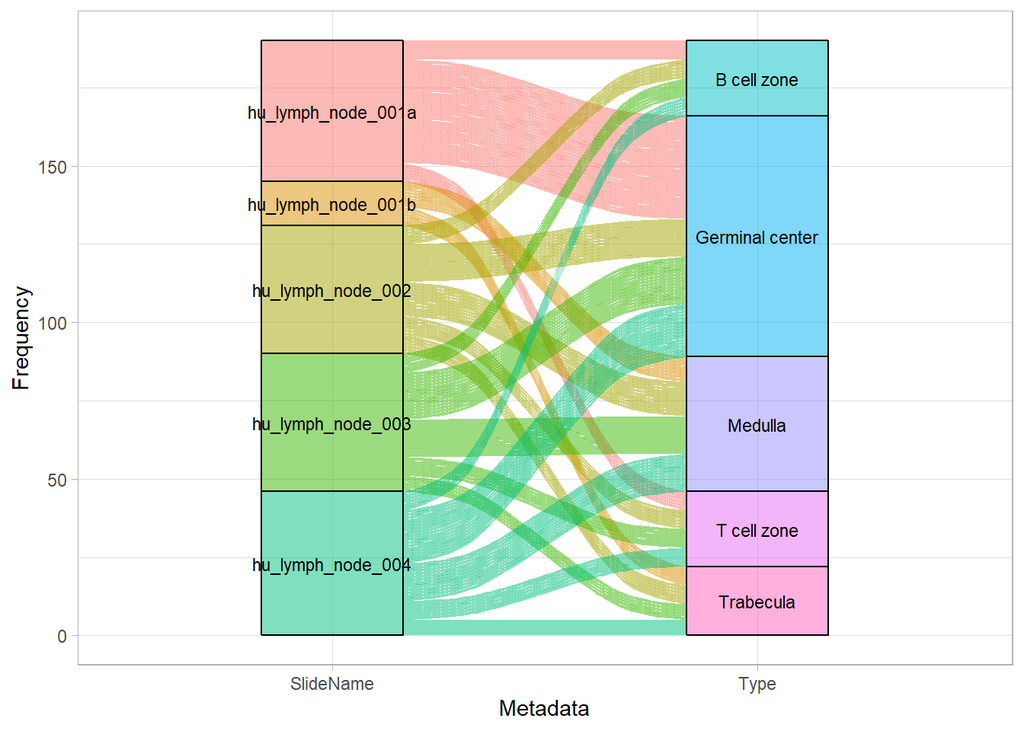

```r
plotSampleInfo(datos, column2plot = c("SlideName", "Type"))
```

Probamos también el que hicimos con GeoMxTools

```r
link1 <- as.data.frame(table(datos$SlideName, datos$Type))
colnames(link1) <- c("source", "target", "value")
nodes <- data.frame(name = unique(c(link1$source, link1$target)))

# Convertir a índices 0-based para sankeyNetwork
link1$source <- match(link1$source, nodes$name) - 1
link1$target <- match(link1$target, nodes$name) - 1

sankeyNetwork(
Links = link1,
Nodes = nodes,
Source = "source",
Target = "target",
Value = "value",
NodeID = "name",
fontSize = 12,
nodeWidth = 30
)
```

[interactive chart not shown]

# 2.2 Control de calidad (QC) de genes

Ahora revisamos los datos a nivel de gen. Con la función addPerROIQC podemos añadir estadísticas importantes al colData del objeto. En este ejercicio usaremos rm_genes = TRUE y los valores por defecto min_count = 5 y sample_fraction = 0.9. Se calcula para cada gen si tiene como mínimo 5 counts en el 90% de los ROI.

```r
datos <- addPerROIQC(datos, rm_genes = TRUE)

dim(datos)
```

```
## [1] 18676   190
```

No hay ningún gen que haya sido eliminado.

Con la función plotGeneQC podemos evaluar las expresiones en logCPM de los genes que fueron eliminados en las distintas muestras. La función también incluye un histograma que muestra la distribución del porcentaje de genes no expresados en todos los ROIs. Por defecto se grafican los 9 genes principales (ordenados por su expresión media), pero esto puede modificarse con el parámetro top_n.

Además, se pueden ordenar las muestras (con ordannots) o colorear y cambiar la forma de los puntos según anotaciones específicas para examinar mejor factores biológicos o experimentales que influyen en la expresión de esos genes (por ejemplo, genes muy expresados en ciertos tipos de tejido o bajo determinadas condiciones de tratamiento). Estos genes deben ser evaluados por expertos para determinar si tienen importancia biológica o experimental, lo cual también sirve como advertencia sobre si los experimentos funcionaron como se esperaba.

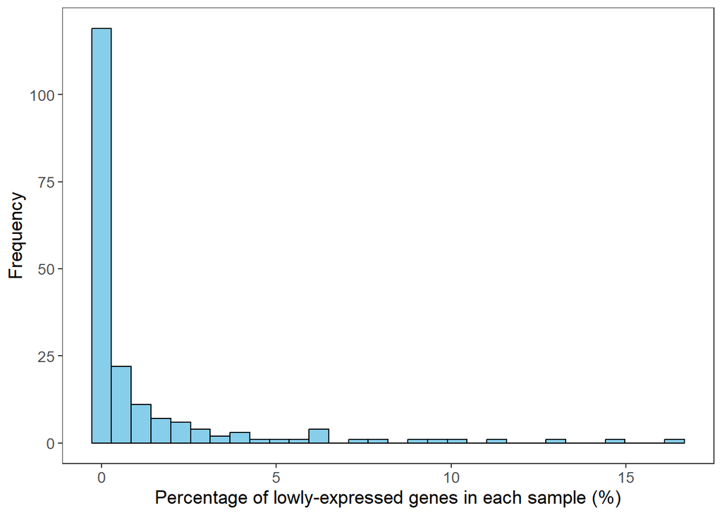

```r
plotGeneQC(datos, ordannots = "regions", col = regions, point_size = 2)
```

# 2.3 Control de calidad (QC) de ROIs

En el control de calidad a nivel de ROI, primero se busca identificar ROI(s) con bajo tamaño de biblioteca y/o bajo recuento de células, ya que se consideran muestras de baja calidad por insuficiente profundidad de secuenciación o falta de ARN en la región seleccionada. Se incluyen histogramas de frecuencia tanto para el tamaño de biblioteca como para el recuento de núcleos, lo que ayuda a detectar distribuciones anómalas.

Para filtrar muestras de baja calidad, se define un umbral mínimo de recuento de células, en este caso 150 células. Además, se puede investigar si los ROI de baja calidad provienen de uno o dos experimentos específicos, estratificando los puntos por nombre de lámina (slide).

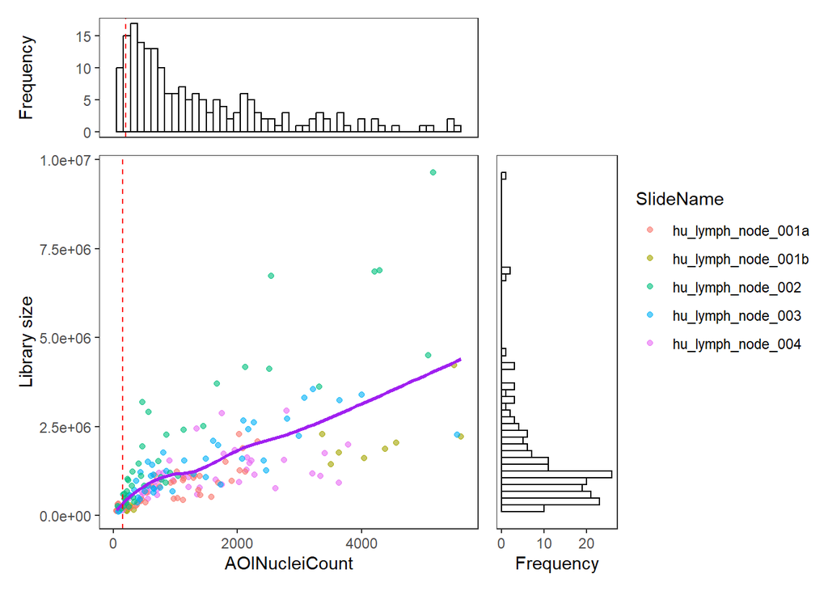

```r
plotROIQC(datos, x_threshold = 150, color = SlideName)
```

Se evalúa la relación entre el tamaño de biblioteca y el recuento de núcleos mediante un gráfico de dispersión, donde se espera una correlación positiva. Es normal encontrar algunos ROI con tamaño de biblioteca relativamente bajo pero con un número razonable de células. En este dataset, la relación entre tamaño de biblioteca y recuento de células es relativamente estable, sin anomalías evidentes.

```r
qc <- colData(datos)$AOINucleiCount > 150
table(qc)
```

```
## qc
## FALSE  TRUE
##    11   179
```

```r
datos <- datos[,qc]
```

Tenemos 11 ROI que no cumplen con tener más de 150 núcleos celulares por ROI.

La función plotROIQC analiza por defecto el recuento de núcleos y el tamaño de la biblioteca de cada ROI. Se puede cambiar los ejes x o y para cualquier otra estadística que se desee evaluar, usando los parámetros x_axis o y_axis. Por ejemplo, se puede graficar el tamaño del área frente al tamaño de la biblioteca.

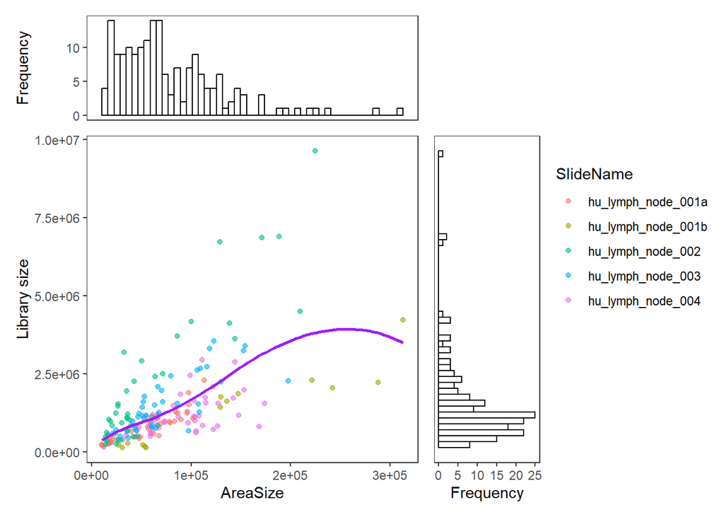

```r
plotROIQC(datos,  x_axis = "AOISurfaceArea", x_lab = "AreaSize", y_axis = "lib_size", y_lab = "Library size", col = SlideName)
```

# 2.4 Relative log expresion distributiin (RLE)

Después del filtrado, usamos la función plotRLExpr para visualizar la expresión logarítmica relativa (RLE) de los datos y detectar posibles variaciones técnicas. Se analiza la distancia relativa entre la mediana del RLE de cada ROI (el punto en el diagrama de caja) y el cero. Cuanto más cerca de cero la distancia, más comparables son los datos entre ellos y menos variabilidad técnica hay en los datos.

Por defecto, se grafica el RLE de los conteos sin normalizar, donde se espera que la mayor parte de la variación se deba a diferencias en el tamaño de la biblioteca.

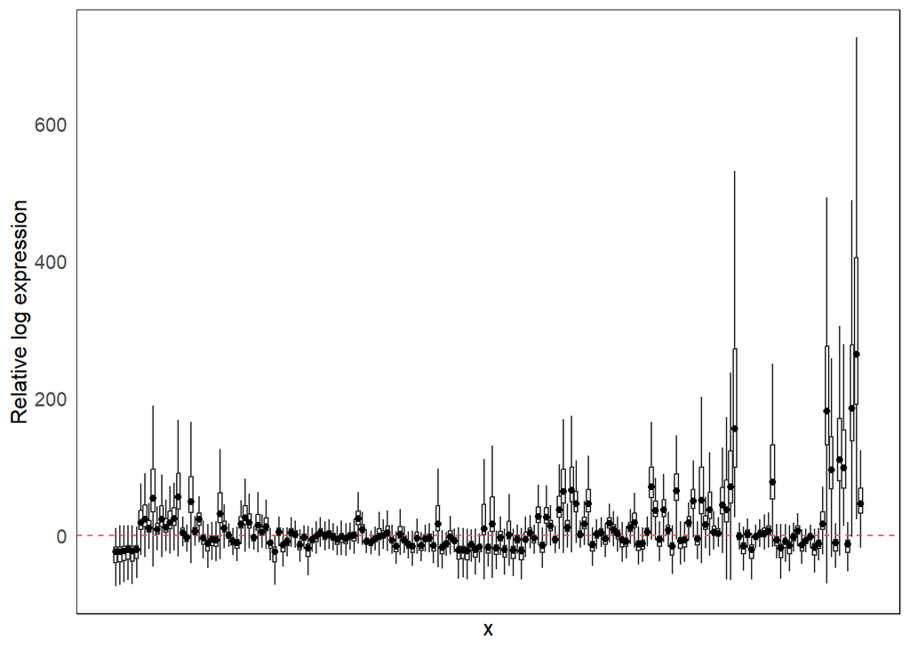

```r
plotRLExpr(datos)
```

Usando assay = 2, se reduce muchisimo esta variación técnica.

Podemos analizarla en ordannots = ‘SlideName’ o ‘Type’

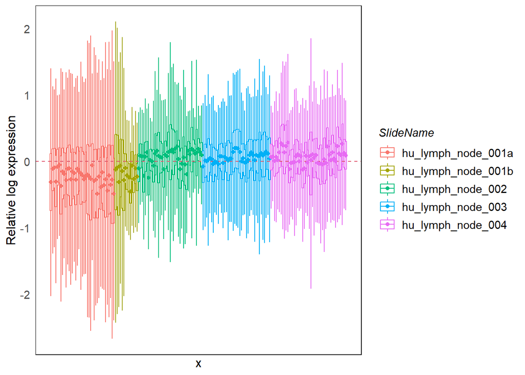

```r
plotRLExpr(datos, ordannots = "SlideName", assay = 2, color = SlideName)
```

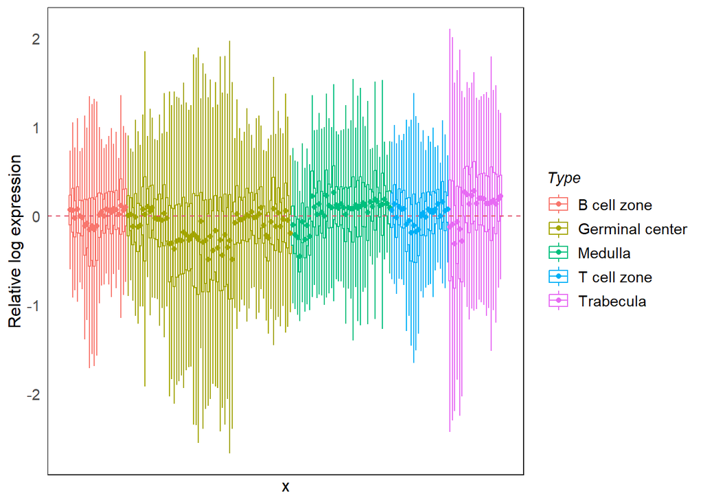

```r
plotRLExpr(datos, ordannots = "Type", assay = 2, color = Type)
```

Se ven en ambos casos más diferencias entre grupos que intra grupos.

# 2.5 Reducción de dimensionalidad

# Análisis de Componentes Principales (PCA)

Podemos realizar un análisis de componentes principales sobre los datos. El PCA ayuda a visualizar posibles variaciones sistémicas (tanto biológicas como técnicas) y a identificar los factores principales que contribuyen a dichas variaciones.

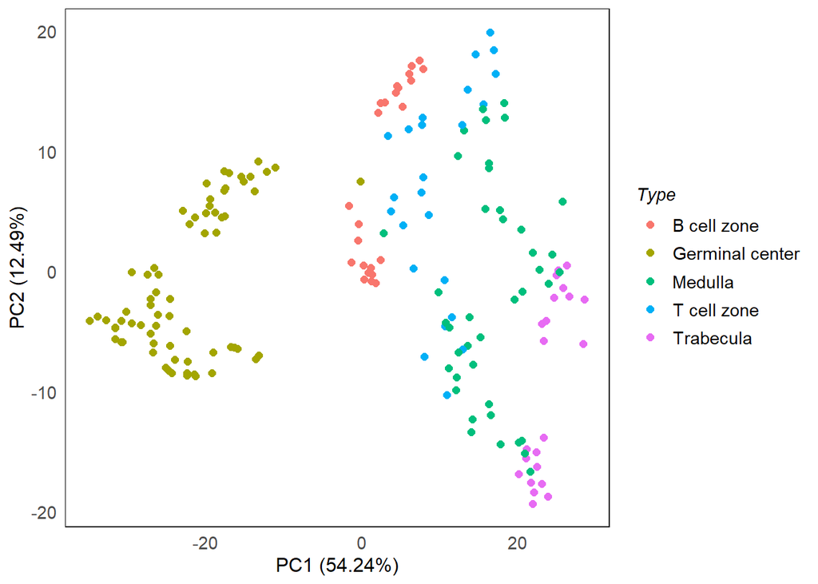

```r
set.seed(100)
datos <- scater::runPCA(datos)
pca_results <- reducedDim(datos, "PCA")
drawPCA(datos, precomputed = pca_results, col = Type)
```

Ahora estratificamos para SlideName

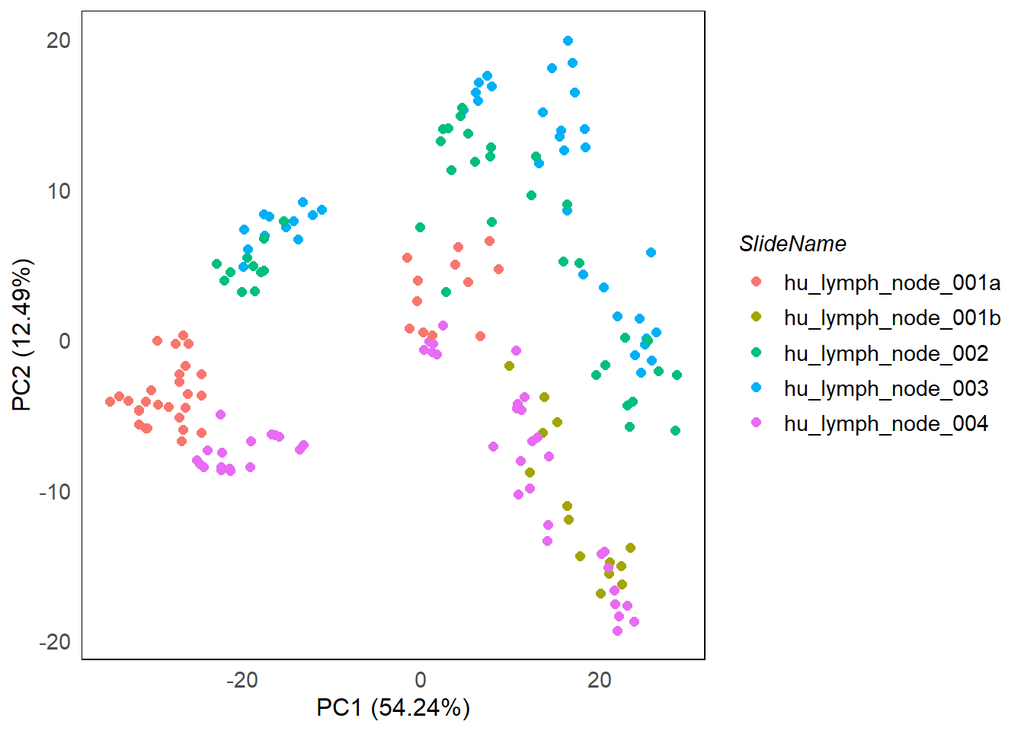

```r
drawPCA(datos, precomputed = pca_results, col = SlideName)
```

Otras funciones del paquete standR para la visualización de los PCAs.

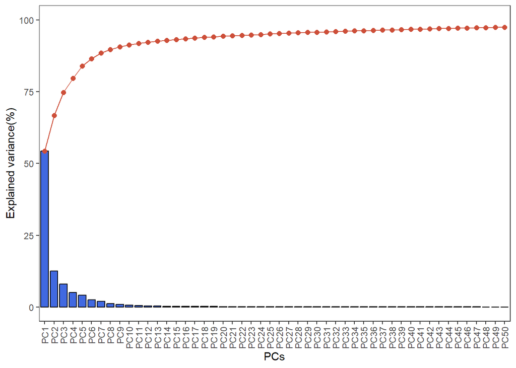

```r
plotScreePCA(datos, precomputed = pca_results)
```

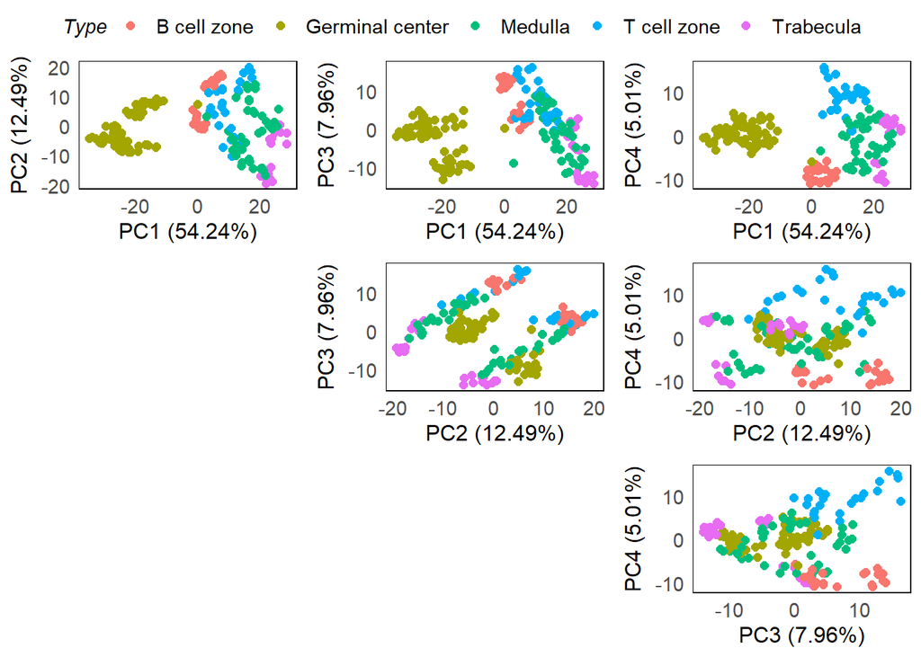

```r
plotPairPCA(datos, col = Type, precomputed = pca_results, n_dimension = 4)
```

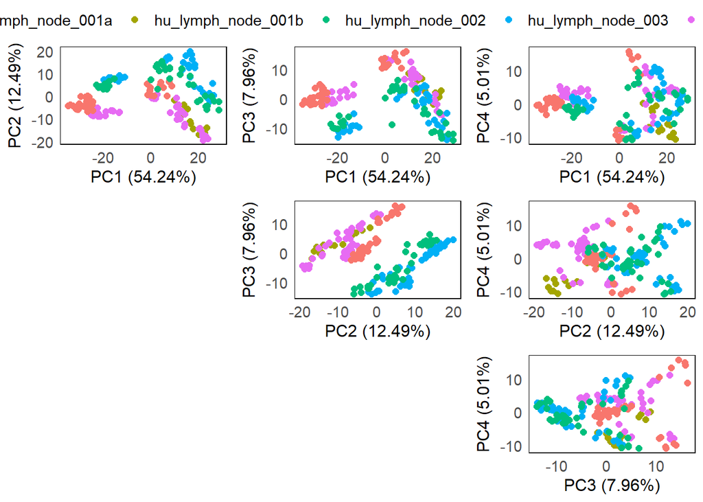

```r
plotPairPCA(datos, col = SlideName, precomputed = pca_results, n_dimension = 4)
```

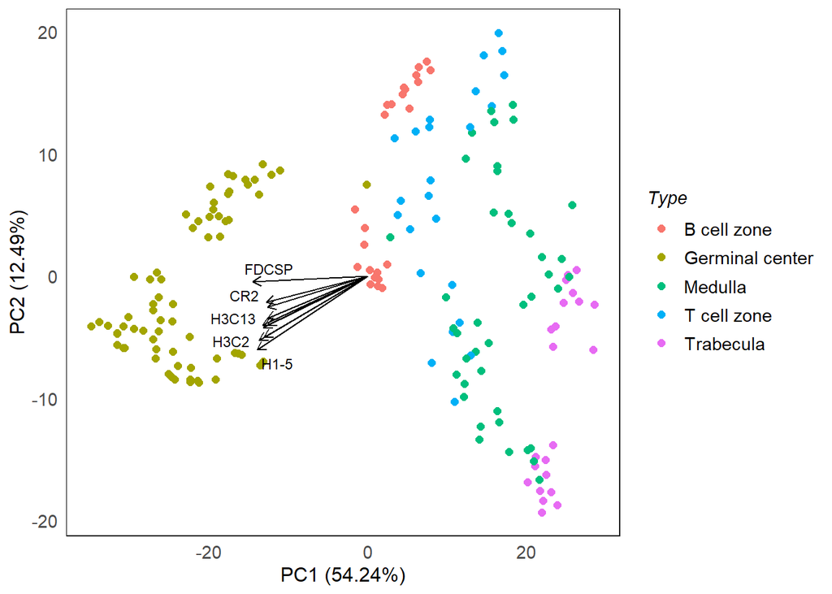

```r
plotPCAbiplot(datos, n_loadings = 10, precomputed = pca_results, col = Type)
```

# Multidimensional Scaling (MDS) Otra forma de reducir dimensionalidad es mediante el MDS.

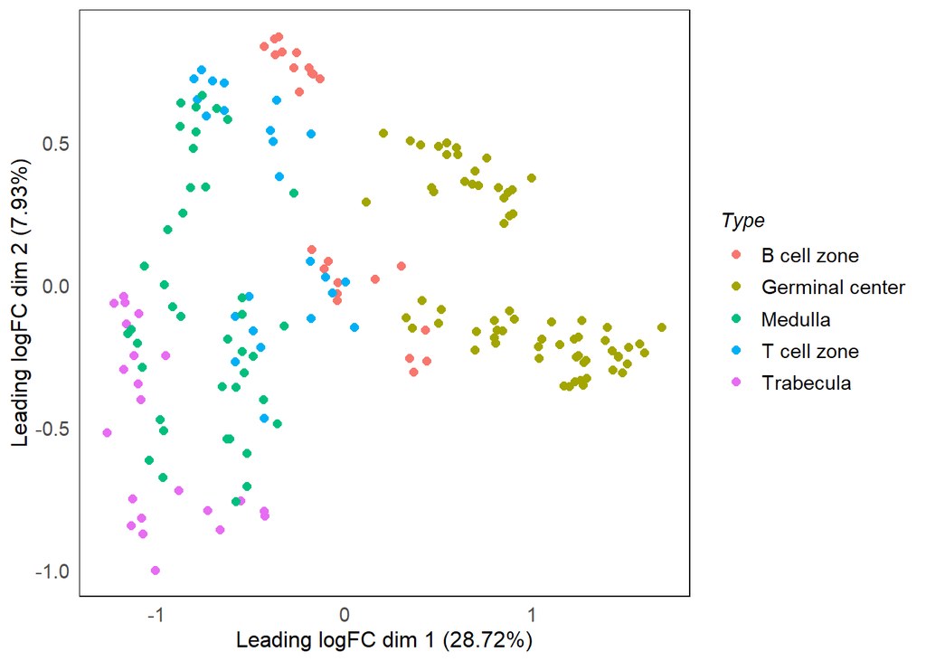

```r
standR::plotMDS(datos, assay = 2, color = Type)
```

# Uniform Manifold Approximation and Projection (UMAP) Otro metodo es UMAP

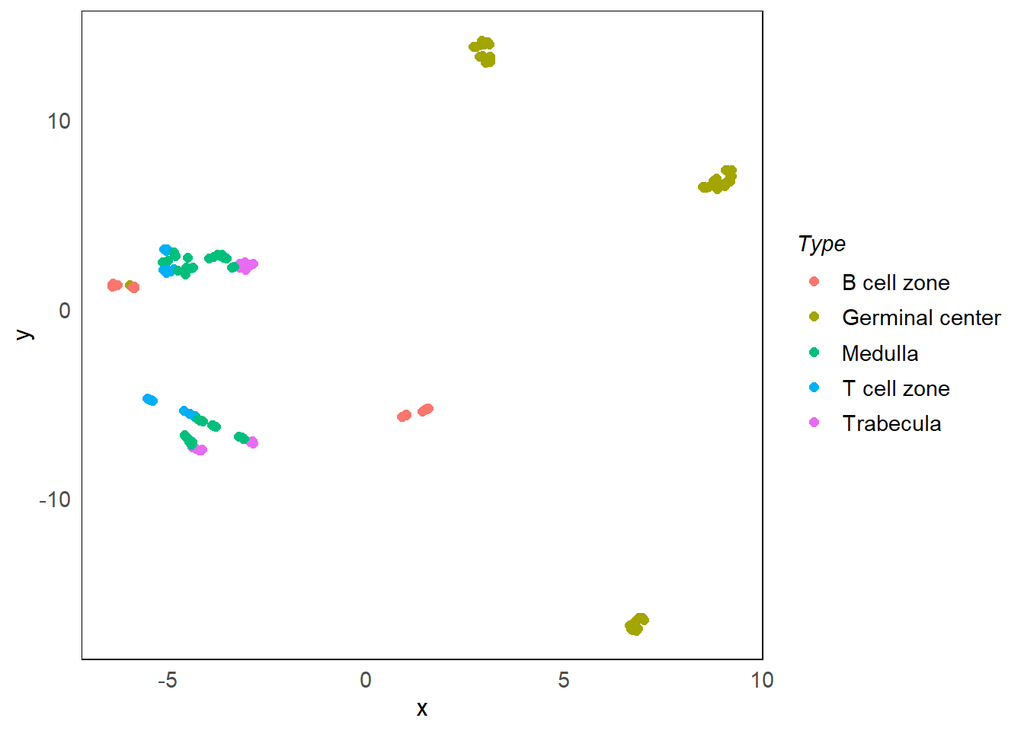

```r
set.seed(100)

datos <- scater::runUMAP(datos, dimred = "PCA")

plotDR(datos, dimred = "UMAP", col = Type)
```

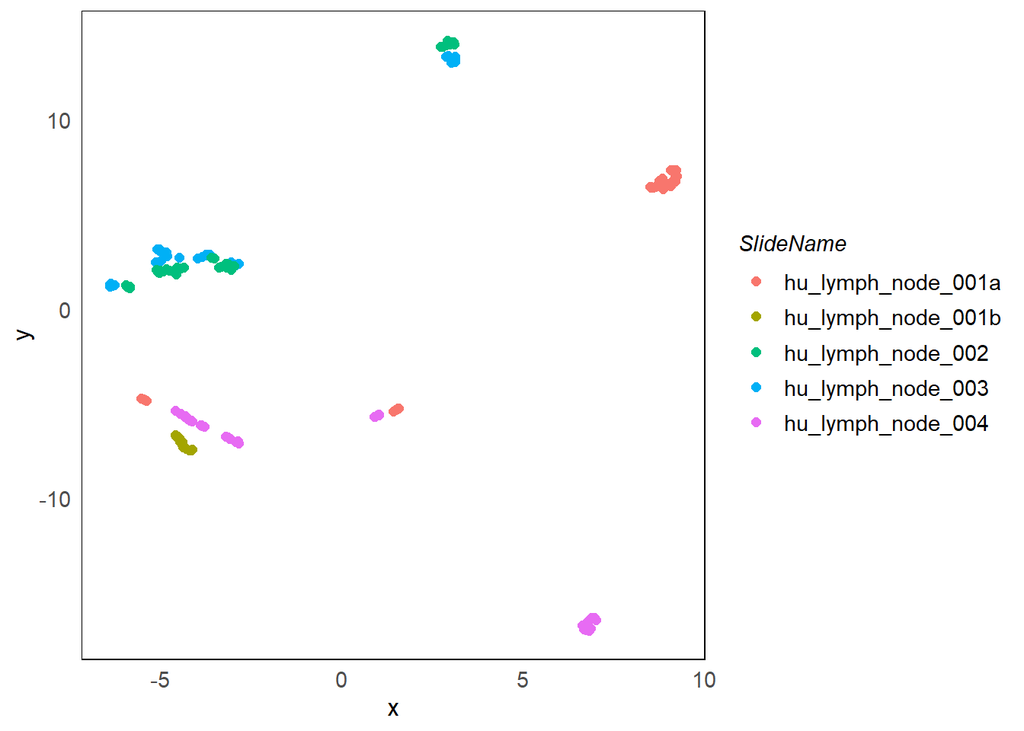

```r
plotDR(datos, dimred = "UMAP", col = SlideName)
```